# Integrated Preterm Birth Prediction: Clinical and Microbiome-Based Machine Learning

## 11.2 Variable Selection Visualization (Approach 3)

**Purpose:** Visualize the frequency and stability of variable selection across the 5 cross-validation folds for the data-driven approach.

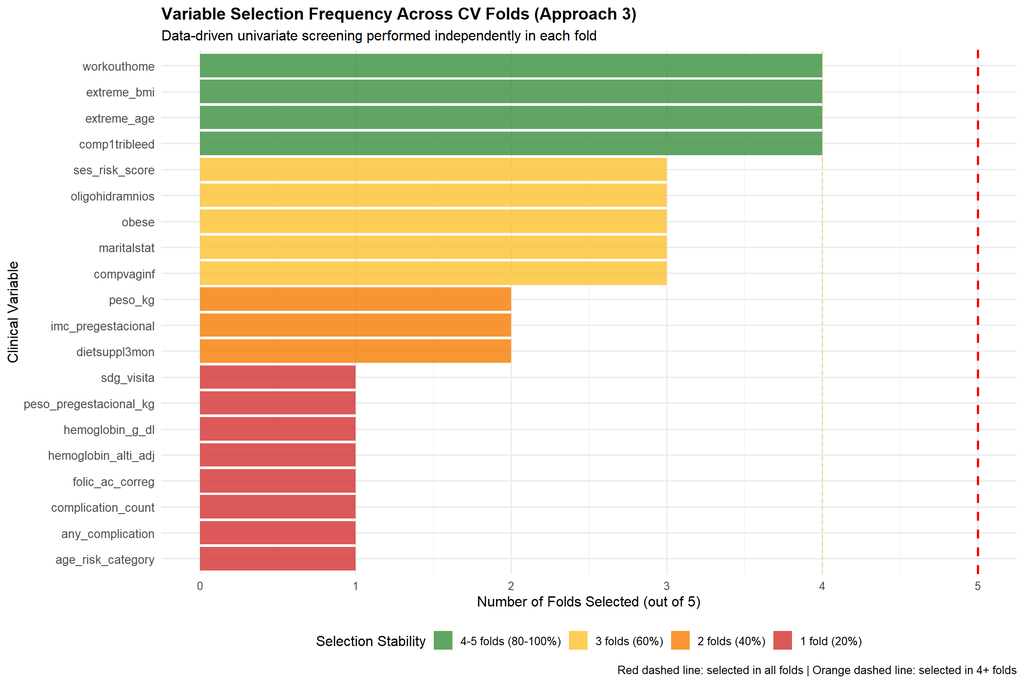

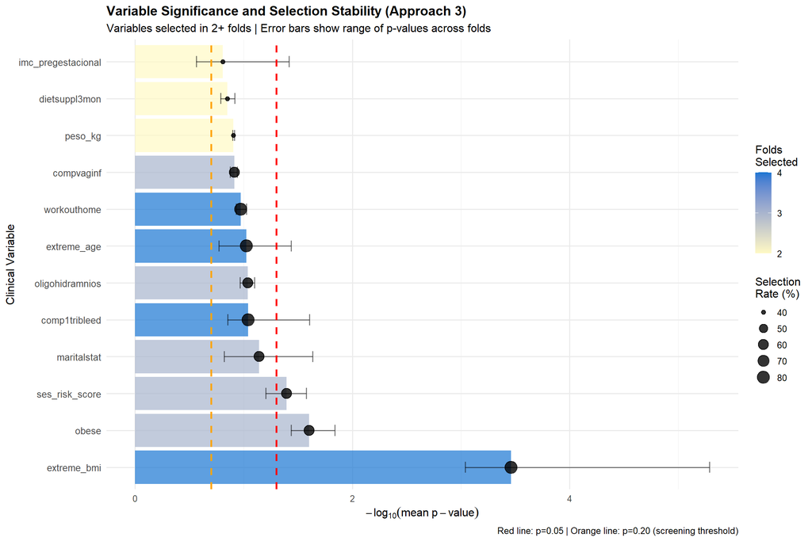

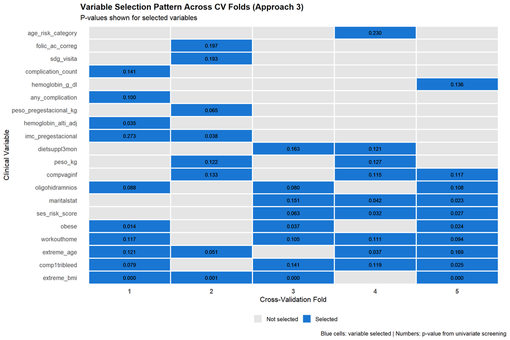

```
##
##
## === VARIABLE SELECTION SUMMARY (APPROACH 3) ===
##
## # A tibble: 1 × 5
##   Very Stable (5 folds…¹ `Stable (4 folds)` `Moderate (3 folds)` `Low (2 folds)`
##                    <int>              <int>                <int>           <int>
## 1                      0                  4                    5               3
## # ℹ abbreviated name: ¹`Very Stable (5 folds)`
## # ℹ 1 more variable: `Unstable (1 fold)` <int>
##
##
## Most stable variables (selected in all 5 folds):
##   None (no variables selected in all 5 folds)
##
##
## Detailed selection statistics:
## # A tibble: 20 × 6
##    Variable   `Folds Selected` `Selection Rate (%)` `Mean p-value` `Min p-value`
##    <chr>                 <int>                <dbl>          <dbl>         <dbl>
##  1 extreme_b…                4                   80       0.000345    0.00000513
##  2 comp1trib…                4                   80       0.0910      0.0249
##  3 extreme_a…                4                   80       0.0944      0.0365
##  4 workoutho…                4                   80       0.107       0.0943
##  5 obese                     3                   60       0.0250      0.0145
##  6 ses_risk_…                3                   60       0.0404      0.0265
##  7 maritalst…                3                   60       0.0721      0.0232
##  8 oligohidr…                3                   60       0.0920      0.0796
##  9 compvaginf                3                   60       0.122       0.115
## 10 peso_kg                   2                   40       0.124       0.122
## 11 dietsuppl…                2                   40       0.142       0.121
## 12 imc_prege…                2                   40       0.155       0.0382
## 13 hemoglobi…                1                   20       0.0348      0.0348
## 14 peso_preg…                1                   20       0.0650      0.0650
## 15 any_compl…                1                   20       0.0996      0.0996
## 16 hemoglobi…                1                   20       0.136       0.136
## 17 complicat…                1                   20       0.141       0.141
## 18 sdg_visita                1                   20       0.193       0.193
## 19 folic_ac_…                1                   20       0.197       0.197
## 20 age_risk_…                1                   20       0.230       0.230
## # ℹ 1 more variable: `Max p-value` <dbl>
```

```r
# Extract variable selection data for Approach 3
approach3_selection_data <- list()

for(result in cv_results_all) {
  if(!is.null(result) &&
     result$approach == "Approach3_DataDriven" &&
     !is.null(result$selected_variables)) {

    model_id <- paste(result$model_name, result$microbiome, sep = "_")
    approach3_selection_data[[model_id]] <- result$selected_variables
  }
}

if(length(approach3_selection_data) > 0) {

  # Combine all selections across models
  all_selections_approach3 <- bind_rows(
    approach3_selection_data,
    .id = "model_config"
  )

  # Calculate selection frequency
  var_frequency_approach3 <- all_selections_approach3 %>%
    group_by(variable) %>%
    summarize(
      n_folds_selected = n_distinct(fold),
      total_folds = 5,
      selection_rate = n_folds_selected / 5 * 100,
      mean_p_value = mean(p_value, na.rm = TRUE),
      min_p_value = min(p_value, na.rm = TRUE),
      max_p_value = max(p_value, na.rm = TRUE),
      .groups = "drop"
    ) %>%
    arrange(desc(n_folds_selected), mean_p_value)

  # ========================================================================
  # VISUALIZATION 1: Selection Frequency Bar Plot
  # ========================================================================

  p1 <- var_frequency_approach3 %>%
    mutate(
      selection_category = case_when(
        n_folds_selected == 5 ~ "All 5 folds (100%)",
        n_folds_selected >= 4 ~ "4-5 folds (80-100%)",
        n_folds_selected >= 3 ~ "3 folds (60%)",
        n_folds_selected >= 2 ~ "2 folds (40%)",
        TRUE ~ "1 fold (20%)"
      ),
      selection_category = factor(
        selection_category,
        levels = c("All 5 folds (100%)", "4-5 folds (80-100%)",
                   "3 folds (60%)", "2 folds (40%)", "1 fold (20%)")
      )
    ) %>%
    ggplot(aes(x = reorder(variable, n_folds_selected),
               y = n_folds_selected)) +
    geom_col(aes(fill = selection_category), alpha = 0.8) +
    geom_hline(yintercept = 5, linetype = "dashed",
               color = "red", size = 1) +
    geom_hline(yintercept = 4, linetype = "dashed",
               color = "orange", size = 0.5, alpha = 0.5) +
    scale_fill_manual(
      name = "Selection Stability",
      values = c(
        "All 5 folds (100%)" = "#1B5E20",
        "4-5 folds (80-100%)" = "#388E3C",
        "3 folds (60%)" = "#FBC02D",
        "2 folds (40%)" = "#F57C00",
        "1 fold (20%)" = "#D32F2F"
      )
    ) +
    coord_flip() +
    labs(
      title = "Variable Selection Frequency Across CV Folds (Approach 3)",
      subtitle = "Data-driven univariate screening performed independently in each fold",
      x = "Clinical Variable",
      y = "Number of Folds Selected (out of 5)",
      caption = "Red dashed line: selected in all folds | Orange dashed line: selected in 4+ folds"
    ) +
    theme_minimal(base_size = 12) +
    theme(
      legend.position = "bottom",
      plot.title = element_text(face = "bold", size = 14),
      axis.text.y = element_text(size = 10)
    )

  print(p1)

  # ========================================================================
  # VISUALIZATION 2: P-value Ranges with Selection Frequency
  # ========================================================================

  p2 <- var_frequency_approach3 %>%
    filter(n_folds_selected >= 2) %>%  # Show variables selected in 2+ folds
    ggplot(aes(x = reorder(variable, mean_p_value),
               y = -log10(mean_p_value))) +
    geom_col(aes(fill = n_folds_selected), alpha = 0.7) +
    geom_errorbar(
      aes(ymin = -log10(max_p_value),
          ymax = -log10(min_p_value)),
      width = 0.3, alpha = 0.5
    ) +
    geom_point(aes(size = selection_rate), alpha = 0.8) +
    geom_hline(yintercept = -log10(0.05), linetype = "dashed",
               color = "red", size = 1) +
    geom_hline(yintercept = -log10(0.20), linetype = "dashed",
               color = "orange", size = 1) +
    scale_fill_gradient(
      low = "#FFF9C4",
      high = "#1976D2",
      name = "Folds\nSelected",
      breaks = c(2, 3, 4, 5)
    ) +
    scale_size_continuous(
      name = "Selection\nRate (%)",
      range = c(2, 6)
    ) +
    coord_flip() +
    labs(
      title = "Variable Significance and Selection Stability (Approach 3)",
      subtitle = "Variables selected in 2+ folds | Error bars show range of p-values across folds",
      x = "Clinical Variable",
      y = expression(-log[10](mean~p-value)),
      caption = "Red line: p=0.05 | Orange line: p=0.20 (screening threshold)"
    ) +
    theme_minimal(base_size = 12) +
    theme(
      legend.position = "right",
      plot.title = element_text(face = "bold", size = 14),
      axis.text.y = element_text(size = 10)
    )

  print(p2)

  # ========================================================================
  # VISUALIZATION 3: Heatmap of Selection Across Folds
  # ========================================================================

  # Prepare data for heatmap
  selection_matrix <- all_selections_approach3 %>%
    select(fold, variable) %>%
    distinct() %>%
    mutate(selected = 1) %>%
    complete(fold = 1:5,
             variable = unique(all_selections_approach3$variable),
             fill = list(selected = 0))

  # Add p-values
  selection_matrix <- selection_matrix %>%
    left_join(
      all_selections_approach3 %>%
        select(fold, variable, p_value),
      by = c("fold", "variable")
    )

  # Calculate selection frequency for ordering
  var_order <- var_frequency_approach3 %>%
    arrange(desc(n_folds_selected), mean_p_value) %>%
    pull(variable)

  p3 <- selection_matrix %>%
    mutate(
      variable = factor(variable, levels = var_order),
      fold = factor(fold, levels = 1:5),
      p_value_label = ifelse(selected == 1,
                              sprintf("%.3f", p_value),
                              "")
    ) %>%
    ggplot(aes(x = fold, y = variable, fill = as.factor(selected))) +
    geom_tile(color = "white", size = 1) +
    geom_text(aes(label = p_value_label), size = 3, color = "black") +
    scale_fill_manual(
      values = c("0" = "gray90", "1" = "#1976D2"),
      labels = c("Not selected", "Selected"),
      name = ""
    ) +
    labs(
      title = "Variable Selection Pattern Across CV Folds (Approach 3)",
      subtitle = "P-values shown for selected variables",
      x = "Cross-Validation Fold",
      y = "Clinical Variable",
      caption = "Blue cells: variable selected | Numbers: p-value from univariate screening"
    ) +
    theme_minimal(base_size = 12) +
    theme(
      plot.title = element_text(face = "bold", size = 14),
      axis.text.x = element_text(size = 11, face = "bold"),
      axis.text.y = element_text(size = 10),
      legend.position = "bottom",
      panel.grid = element_blank()
    )

  print(p3)

  # ========================================================================
  # SUMMARY TABLE
  # ========================================================================

  cat("\n\n=== VARIABLE SELECTION SUMMARY (APPROACH 3) ===\n\n")

  stability_summary <- var_frequency_approach3 %>%
    summarize(
      `Very Stable (5 folds)` = sum(n_folds_selected == 5),
      `Stable (4 folds)` = sum(n_folds_selected == 4),
      `Moderate (3 folds)` = sum(n_folds_selected == 3),
      `Low (2 folds)` = sum(n_folds_selected == 2),
      `Unstable (1 fold)` = sum(n_folds_selected == 1)
    )

  print(stability_summary)

  cat("\n\nMost stable variables (selected in all 5 folds):\n")
  most_stable <- var_frequency_approach3 %>%
    filter(n_folds_selected == 5) %>%
    arrange(mean_p_value)

  if(nrow(most_stable) > 0) {
    for(i in 1:nrow(most_stable)) {
      cat(sprintf("  %d. %s (mean p=%.4f)\n",
                  i,
                  most_stable$variable[i],
                  most_stable$mean_p_value[i]))
    }
  } else {
    cat("  None (no variables selected in all 5 folds)\n")
  }

  # Detailed table
  cat("\n\nDetailed selection statistics:\n")
  print(var_frequency_approach3 %>%
          arrange(desc(n_folds_selected), mean_p_value) %>%
          select(Variable = variable,
                 `Folds Selected` = n_folds_selected,
                 `Selection Rate (%)` = selection_rate,
                 `Mean p-value` = mean_p_value,
                 `Min p-value` = min_p_value,
                 `Max p-value` = max_p_value))

} else {
  cat("No Approach 3 results with variable selection data found.\n")
}
```

**Interpretation of Selection Variability:**

The absence of variables selected in all 5 folds reflects the expected behavior of data-driven selection with small samples (n~34 per fold). Key observations:

The presence of several moderately stable variables (60-80% selection rate) provides confidence that data-driven selection identifies genuine signals rather than pure noise, while the absence of universally selected variables reflects the statistical reality of small-sample inference.

## 11.3 Taxa Selection Visualization (ANCOM-BC2)

**Purpose:** Visualize which microbiome taxa were selected across CV folds when using ANCOM-BC2 differential abundance analysis.

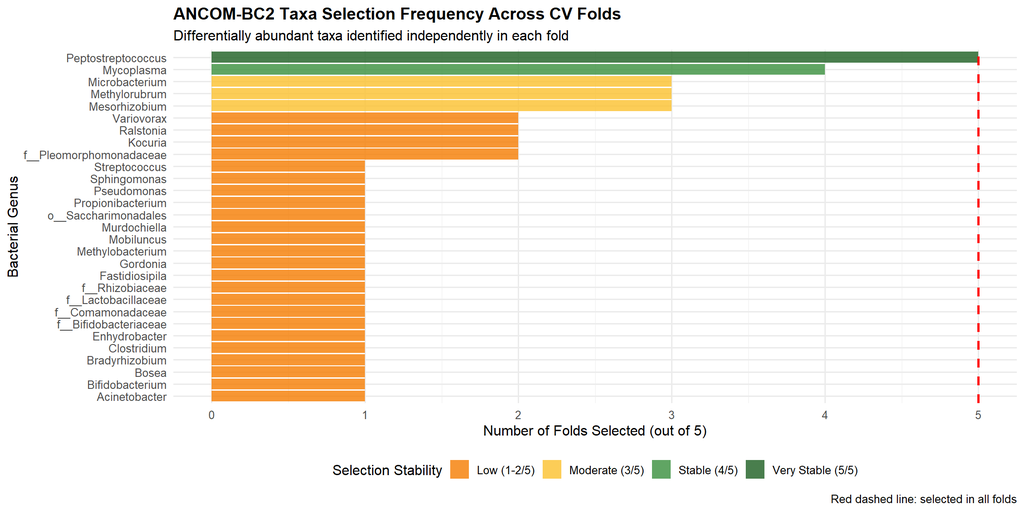

```
##
## === TAXA SELECTION SUMMARY ===
##
## # A tibble: 29 × 3
##    Taxon                   `Folds Selected` `Selection Rate (%)`
##    <chr>                              <int>                <dbl>
##  1 Peptostreptococcus                     5                  100
##  2 Mycoplasma                             4                   80
##  3 Mesorhizobium                          3                   60
##  4 Methylorubrum                          3                   60
##  5 Microbacterium                         3                   60
##  6 Kocuria                                2                   40
##  7 Ralstonia                              2                   40
##  8 Variovorax                             2                   40
##  9 f__Pleomorphomonadaceae                2                   40
## 10 Acinetobacter                          1                   20
## # ℹ 19 more rows
```

```r
# Extract taxa selection data
ancom_selection_data <- list()

for(result in cv_results_all) {
  if(!is.null(result) &&
     result$microbiome == "ANCOM_Taxa" &&
     !is.null(result$selected_taxa)) {

    model_id <- paste(result$model_name, result$approach, sep = "_")
    ancom_selection_data[[model_id]] <- result$selected_taxa
  }
}

if(length(ancom_selection_data) > 0) {

  all_taxa_selections <- bind_rows(ancom_selection_data, .id = "model_config")

  # Calculate taxa selection frequency
  taxa_frequency <- all_taxa_selections %>%
    group_by(taxon) %>%
    summarize(
      n_folds_selected = n_distinct(fold),
      selection_rate = n_folds_selected / 5 * 100,
      .groups = "drop"
    ) %>%
    arrange(desc(n_folds_selected))

  # Visualization
  p_taxa <- taxa_frequency %>%
    mutate(
      stability = case_when(
        n_folds_selected == 5 ~ "Very Stable (5/5)",
        n_folds_selected >= 4 ~ "Stable (4/5)",
        n_folds_selected >= 3 ~ "Moderate (3/5)",
        TRUE ~ "Low (1-2/5)"
      )
    ) %>%
    ggplot(aes(x = reorder(taxon, n_folds_selected), y = n_folds_selected)) +
    geom_col(aes(fill = stability), alpha = 0.8) +
    geom_hline(yintercept = 5, linetype = "dashed", color = "red", size = 1) +
    scale_fill_manual(
      values = c(
        "Very Stable (5/5)" = "#1B5E20",
        "Stable (4/5)" = "#388E3C",
        "Moderate (3/5)" = "#FBC02D",
        "Low (1-2/5)" = "#F57C00"
      ),
      name = "Selection Stability"
    ) +
    coord_flip() +
    labs(
      title = "ANCOM-BC2 Taxa Selection Frequency Across CV Folds",
      subtitle = "Differentially abundant taxa identified independently in each fold",
      x = "Bacterial Genus",
      y = "Number of Folds Selected (out of 5)",
      caption = "Red dashed line: selected in all folds"
    ) +
    theme_minimal(base_size = 12) +
    theme(
      legend.position = "bottom",
      plot.title = element_text(face = "bold", size = 14)
    )

  print(p_taxa)

  cat("\n=== TAXA SELECTION SUMMARY ===\n\n")
  print(taxa_frequency %>%
          arrange(desc(n_folds_selected)) %>%
          select(Taxon = taxon,
                 `Folds Selected` = n_folds_selected,
                 `Selection Rate (%)` = selection_rate))

} else {
  cat("No ANCOM taxa selection data found.\n")
}
```

**Interpretation of Taxa Selection Patterns:**

**Reproducibly identified taxa** (selected in ≥60% of folds): - **Peptostreptococcus** (100%): Only taxon selected in all folds; strong candidate for PTB biomarker in Mexican women - **Mycoplasma** (80%): Established reproductive pathogen; high stability supports causal role - **Environmental taxa** (60%): Mesorhizobium, Methylorubrum, Microbacterium show surprising stability

**Biological vs. Technical Signals:**

The high stability of environmental taxa raises important questions:

*Technical explanation (contamination):* - Low-biomass vaginal samples prone to reagent contamination - Environmental bacteria common contaminants in extraction kits and PCR reagents - Stability across folds suggests systematic rather than random contamination

*Biological explanation (true exposures):* - Occupational exposures (agricultural work common in Puebla, Mexico) - Dietary sources (fermented foods, unwashed produce) - Hygiene practices varying between PTB and term pregnancies

**Critical need:** Future studies must implement rigorous negative controls (extraction blanks, PCR blanks) to distinguish between these possibilities. The stability of environmental taxa indicates they are genuine signals in this dataset—whether biological or technical—rather than random noise.

**Clinical relevance:** Even if environmental taxa represent contamination, their consistent association with PTB outcomes suggests potential utility as “nuisance biomarkers.” However, reliance on potentially artifactual signals would be scientifically unsatisfying and clinically risky without mechanistic understanding.

## 11.4 PERFORMANCE TABLE: NESTED CV RESULTS

Purpose: Generate publication-ready table of model performance metrics

This chunk transforms the cv_results_all list into a formatted table suitable for inclusion in manuscripts. The table includes: - Model identification (algorithm, approach, microbiome) - Threshold-independent metrics (AUROC, PRAUC) - Threshold-dependent metrics (Sensitivity, Specificity, Accuracy) - Performance reported as mean ± SD across 5 folds

Table features: - Sorted by AUROC (descending) to highlight best-performing models - Color-coded top 3 models for visual emphasis - Professional formatting using kableExtra - Footnotes explaining methodology

Output: HTML table with bootstrap styling for presentation

```r
# ============================================================================
# PERFORMANCE TABLE: NESTED CV RESULTS
# ============================================================================

cat("\n=== CREATING PERFORMANCE TABLE ===\n\n")
```

```
##
## === CREATING PERFORMANCE TABLE ===
```

```r
cv_performance <- map_dfr(cv_results_all, function(res) {
  tibble(
    Model = res$model_name,
    Approach = res$approach,
    Microbiome = res$microbiome,
    AUROC = sprintf("%.3f ± %.3f",
                    res$summary$AUROC_mean, res$summary$AUROC_sd),
    PRAUC = sprintf("%.3f ± %.3f",
                    res$summary$PRAUC_mean, res$summary$PRAUC_sd),
    Sensitivity = sprintf("%.3f ± %.3f",
                          res$summary$Sensitivity_mean, res$summary$Sensitivity_sd),
    Specificity = sprintf("%.3f ± %.3f",
                          res$summary$Specificity_mean, res$summary$Specificity_sd),
    Accuracy = sprintf("%.3f ± %.3f",
                       res$summary$Accuracy_mean, res$summary$Accuracy_sd),
    Bal_Accuracy = sprintf("%.3f ± %.3f",
                           res$summary$Balanced_Accuracy_mean,
                           res$summary$Balanced_Accuracy_sd),
    Threshold = sprintf("%.3f ± %.3f",
                        res$summary$threshold_mean, res$summary$threshold_sd),
    Youden = sprintf("%.3f ± %.3f",
                     res$summary$Youden_mean, res$summary$Youden_sd),
    AUROC_mean = res$summary$AUROC_mean,  # For sorting
    PRAUC_mean = res$summary$PRAUC_mean   # For secondary sorting
  )
}) %>%
  arrange(desc(AUROC_mean), desc(PRAUC_mean)) %>%
  select(-AUROC_mean, -PRAUC_mean)

# Display table
kable(cv_performance,
      caption = "Model Performance with Nested Cross-Validation (Mean ± SD across 5 folds)",
      format = "html",
      align = c("l", "l", "l", rep("r", 8))) %>%
  kable_styling(bootstrap_options = c("striped", "hover", "condensed"),
                full_width = FALSE,
                font_size = 10) %>%
  row_spec(0, bold = TRUE, background = "#E3F2FD") %>%
  column_spec(1, bold = TRUE, width = "7em") %>%
  column_spec(2, width = "10em") %>%
  row_spec(1:3, background = "#C8E6C9") %>%
  footnote(
    general = c(
      "Thresholds optimized on inner validation sets using Youden Index.",
      "Performance metrics calculated on independent outer test folds.",
      "This approach avoids data leakage and provides unbiased estimates."
    ),
    general_title = "Notes:",
    footnote_as_chunk = TRUE
  )
```

Model Performance with Nested Cross-Validation (Mean ± SD across 5 folds)

| Model | Approach | Microbiome | AUROC | PRAUC | Sensitivity | Specificity | Accuracy | Bal_Accuracy | Threshold | Youden |
| --- | --- | --- | --- | --- | --- | --- | --- | --- | --- | --- |
| rf_base | Approach3_DataDriven | Full_Microbiome | 0.849 ± 0.130 | 0.571 ± 0.208 | 0.800 ± 0.447 | 0.473 ± 0.426 | 0.584 ± 0.362 | 0.637 ± 0.360 | 0.198 ± 0.037 | 0.273 ± 0.720 |
| rf_base | Approach3_DataDriven | ANCOM_Taxa | 0.782 ± 0.142 | 0.609 ± 0.198 | 0.533 ± 0.380 | 0.760 ± 0.344 | 0.692 ± 0.251 | 0.647 ± 0.250 | 0.276 ± 0.089 | 0.293 ± 0.500 |
| rf_base | Approach1_DREAM | Full_Microbiome | 0.751 ± 0.087 | 0.663 ± 0.217 | 0.667 ± 0.408 | 0.520 ± 0.375 | 0.575 ± 0.243 | 0.593 ± 0.234 | 0.238 ± 0.040 | 0.187 ± 0.468 |
| glmnet_base | Approach2_Literature | ANCOM_Taxa | 0.724 ± 0.140 | 0.784 ± 0.195 | 0.333 ± 0.333 | 0.520 ± 0.315 | 0.463 ± 0.183 | 0.427 ± 0.166 | 0.248 ± 0.146 | -0.147 ± 0.332 |
| rf_base | Approach2_Literature | Full_Microbiome | 0.709 ± 0.135 | 0.643 ± 0.163 | 0.633 ± 0.415 | 0.540 ± 0.288 | 0.568 ± 0.183 | 0.587 ± 0.190 | 0.214 ± 0.025 | 0.173 ± 0.380 |
| glmnet_base | Approach1_DREAM | ANCOM_Taxa | 0.707 ± 0.173 | 0.756 ± 0.179 | 0.500 ± 0.167 | 0.500 ± 0.471 | 0.495 ± 0.290 | 0.500 ± 0.195 | 0.176 ± 0.077 | -0.000 ± 0.391 |
| rf_base | Approach2_Literature | ANCOM_Taxa | 0.687 ± 0.067 | 0.674 ± 0.123 | 0.600 ± 0.435 | 0.560 ± 0.244 | 0.581 ± 0.121 | 0.580 ± 0.160 | 0.266 ± 0.101 | 0.160 ± 0.321 |
| glmnet_base | Approach1_DREAM | Full_Microbiome | 0.680 ± 0.168 | 0.693 ± 0.150 | 0.333 ± 0.408 | 0.860 ± 0.219 | 0.692 ± 0.087 | 0.597 ± 0.143 | 0.406 ± 0.273 | 0.193 ± 0.285 |
| glmnet_base | Approach2_Literature | Full_Microbiome | 0.671 ± 0.161 | 0.768 ± 0.151 | 0.267 ± 0.279 | 0.860 ± 0.080 | 0.670 ± 0.073 | 0.563 ± 0.129 | 0.388 ± 0.187 | 0.127 ± 0.258 |
| glmnet_base | Approach3_DataDriven | ANCOM_Taxa | 0.671 ± 0.249 | 0.580 ± 0.164 | 0.633 ± 0.247 | 0.587 ± 0.382 | 0.603 ± 0.201 | 0.610 ± 0.129 | 0.225 ± 0.191 | 0.220 ± 0.259 |
| rf_base | Approach1_DREAM | ANCOM_Taxa | 0.656 ± 0.107 | 0.634 ± 0.091 | 0.633 ± 0.247 | 0.507 ± 0.325 | 0.546 ± 0.221 | 0.570 ± 0.185 | 0.247 ± 0.048 | 0.140 ± 0.370 |
| glmnet_base | Approach3_DataDriven | Full_Microbiome | 0.616 ± 0.195 | 0.630 ± 0.147 | 0.333 ± 0.236 | 0.860 ± 0.142 | 0.692 ± 0.141 | 0.597 ± 0.165 | 0.349 ± 0.261 | 0.193 ± 0.330 |

Notes: Thresholds optimized on inner validation sets using Youden Index. Performance metrics calculated on independent outer test folds. This approach avoids data leakage and provides unbiased estimates.

```r
cat("\n✓ Performance table created successfully\n")
```

```
##
## ✓ Performance table created successfully
```

```r
cat(sprintf("Total models: %d\n", nrow(cv_performance)))
```

```
## Total models: 12
```

```r
# ============================================================================
# ROC/PR CURVES FROM STORED DATA (NO RETRAINING)
# ============================================================================

cat("\n╔════════════════════════════════════════╗\n")
```

```
##
## ╔════════════════════════════════════════╗
```

```r
cat("║  PLOTTING ROC/PR FROM STORED DATA     ║\n")
```

```
## ║  PLOTTING ROC/PR FROM STORED DATA     ║
```

```r
cat("╚════════════════════════════════════════╝\n\n")
```

```
## ╚════════════════════════════════════════╝
```

```r
# Helper function: interpolate to common grid
interpolate_curve <- function(x, y, x_grid) {
  df <- tibble(x = x, y = y) %>% distinct() %>% arrange(x)
  if(nrow(df) < 2) return(rep(mean(y, na.rm = TRUE), length(x_grid)))
  approx(x = df$x, y = df$y, xout = x_grid, method = "linear", rule = 2)$y
}

# ============================================================================
# GET TOP 3 MODELS WITH FULL METRICS
# ============================================================================

top_3_idx <- map_dfr(1:length(cv_results_all), function(i) {
  res <- cv_results_all[[i]]
  tibble(
    idx = i,
    model_name = res$model_name,
    approach = res$approach,
    microbiome = res$microbiome,
    auroc_mean = res$summary$AUROC_mean,
    auroc_sd = res$summary$AUROC_sd,
    prauc_mean = res$summary$PRAUC_mean,
    prauc_sd = res$summary$PRAUC_sd
  )
}) %>%
  arrange(desc(auroc_mean), desc(prauc_mean)) %>%
  head(3) %>%
  mutate(rank = row_number())  # Explicit rank 1, 2, 3

cat("Top 3 models (in order):\n")
```

```
## Top 3 models (in order):
```

```r
print(top_3_idx %>% select(rank, model_name, approach, microbiome, auroc_mean))
```

```
## # A tibble: 3 × 5
##    rank model_name approach             microbiome      auroc_mean
##   <int> <chr>      <chr>                <chr>                <dbl>
## 1     1 rf_base    Approach3_DataDriven Full_Microbiome      0.849
## 2     2 rf_base    Approach3_DataDriven ANCOM_Taxa           0.782
## 3     3 rf_base    Approach1_DREAM      Full_Microbiome      0.751
```

```r
cat("\n")
```

```r
# ============================================================================
# EXTRACT ROC DATA WITH PROPER RANKING
# ============================================================================

roc_data <- map_dfr(1:nrow(top_3_idx), function(i) {
  idx <- top_3_idx$idx[i]
  res <- cv_results_all[[idx]]

  if(is.null(res$roc_curves)) {
    cat(sprintf("WARNING: Model rank %d missing ROC curves\n", i))
    return(NULL)
  }

  # Create label WITH metrics
  model_label_with_metrics <- sprintf(
    "%s | %s | %s\n(AUROC: %.3f ± %.3f)",
    res$model_name,
    gsub("Approach[0-9]_", "", res$approach),
    gsub("_", " ", res$microbiome),
    top_3_idx$auroc_mean[i],
    top_3_idx$auroc_sd[i]
  )

  res$roc_curves %>%
    mutate(
      model_rank = i,  # Explicit rank from top_3_idx order
      model_label = model_label_with_metrics,
      fpr = 1 - specificity
    )
})

if(nrow(roc_data) == 0) {
  stop("No ROC data available. Re-run nested CV with curve storage.")
}

# ============================================================================
# INTERPOLATE ROC CURVES
# ============================================================================

fpr_grid <- seq(0, 1, 0.01)

roc_interp <- roc_data %>%
  group_by(model_label, model_rank, fold) %>%
  arrange(fpr) %>%
  summarize(
    fpr_interp = list(fpr_grid),
    sens_interp = list(interpolate_curve(fpr, sensitivity, fpr_grid)),
    .groups = "drop"
  ) %>%
  unnest(c(fpr_interp, sens_interp))

roc_summary <- roc_interp %>%
  group_by(model_label, model_rank, fpr_interp) %>%
  summarize(
    sens_mean = mean(sens_interp, na.rm = TRUE),
    sens_sd = sd(sens_interp, na.rm = TRUE),
    n = n(),
    .groups = "drop"
  ) %>%
  mutate(
    sens_se = sens_sd / sqrt(n),
    sens_lower = pmax(0, sens_mean - 1.96 * sens_se),
    sens_upper = pmin(1, sens_mean + 1.96 * sens_se)
  )

# ============================================================================
# EXTRACT PR DATA WITH PROPER RANKING
# ============================================================================

pr_data <- map_dfr(1:nrow(top_3_idx), function(i) {
  idx <- top_3_idx$idx[i]
  res <- cv_results_all[[idx]]

  if(is.null(res$pr_curves)) {
    cat(sprintf("WARNING: Model rank %d missing PR curves\n", i))
    return(NULL)
  }

  # Create label WITH metrics
  model_label_with_metrics <- sprintf(
    "%s | %s | %s\n(AUROC: %.3f ± %.3f)",
    res$model_name,
    gsub("Approach[0-9]_", "", res$approach),
    gsub("_", " ", res$microbiome),
    top_3_idx$auroc_mean[i],
    top_3_idx$auroc_sd[i]
  )

  res$pr_curves %>%
    mutate(
      model_rank = i,
      model_label = model_label_with_metrics
    )
})

# ============================================================================
# INTERPOLATE PR CURVES
# ============================================================================

recall_grid <- seq(0, 1, 0.01)

pr_interp <- pr_data %>%
  group_by(model_label, model_rank, fold) %>%
  arrange(recall) %>%
  summarize(
    recall_interp = list(recall_grid),
    prec_interp = list(interpolate_curve(recall, precision, recall_grid)),
    .groups = "drop"
  ) %>%
  unnest(c(recall_interp, prec_interp))

pr_summary <- pr_interp %>%
  group_by(model_label, model_rank, recall_interp) %>%
  summarize(
    prec_mean = mean(prec_interp, na.rm = TRUE),
    prec_sd = sd(prec_interp, na.rm = TRUE),
    n = n(),
    .groups = "drop"
  ) %>%
  mutate(
    prec_se = prec_sd / sqrt(n),
    prec_lower = pmax(0, prec_mean - 1.96 * prec_se),
    prec_upper = pmin(1, prec_mean + 1.96 * prec_se)
  )

# ============================================================================
# COLORS AND LABELS (CRITICAL FIX)
# ============================================================================

# Define colors for ranks
colors <- c("#E74C3C", "#3498DB", "#2ECC71")  # Red, Blue, Green for ranks 1, 2, 3

# Get labels in rank order (1, 2, 3)
labels_ordered <- roc_summary %>%
  distinct(model_rank, model_label) %>%
  arrange(model_rank) %>%
  pull(model_label)

cat("\nColor assignment:\n")
```

```
##
## Color assignment:
```

```r
cat(sprintf("  Rank 1 (Red):   %s\n", gsub("\n.*", "", labels_ordered[1])))
```

```
##   Rank 1 (Red):   rf_base | DataDriven | Full Microbiome
```

```r
cat(sprintf("  Rank 2 (Blue):  %s\n", gsub("\n.*", "", labels_ordered[2])))
```

```
##   Rank 2 (Blue):  rf_base | DataDriven | ANCOM Taxa
```

```r
cat(sprintf("  Rank 3 (Green): %s\n\n", gsub("\n.*", "", labels_ordered[3])))
```

```
##   Rank 3 (Green): rf_base | DREAM | Full Microbiome
```

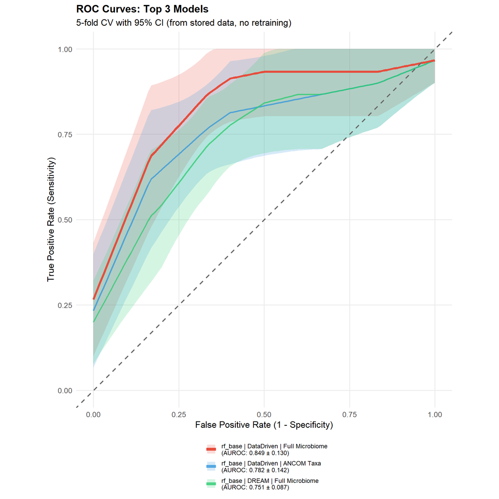

```r
# ============================================================================
# PLOT ROC CURVES
# ============================================================================

p_roc <- ggplot() +
  # Confidence bands
  geom_ribbon(
    data = roc_summary,
    aes(x = fpr_interp,
        ymin = sens_lower,
        ymax = sens_upper,
        fill = factor(model_rank, levels = 1:3)),
    alpha = 0.2
  ) +
  # Lines for ranks 2 and 3 (thinner)
  geom_line(
    data = roc_summary %>% filter(model_rank %in% c(2, 3)),
    aes(x = fpr_interp,
        y = sens_mean,
        color = factor(model_rank, levels = 1:3)),
    linewidth = 1.0,
    alpha = 0.8
  ) +
  # Line for rank 1 (thicker, winner)
  geom_line(
    data = roc_summary %>% filter(model_rank == 1),
    aes(x = fpr_interp,
        y = sens_mean,
        color = factor(model_rank, levels = 1:3)),
    linewidth = 1.5,
    alpha = 1.0
  ) +
  # Diagonal reference
  geom_abline(
    intercept = 0, slope = 1,
    linetype = "dashed",
    color = "gray40",
    linewidth = 0.8
  ) +
  # Color scales with explicit factor levels
  scale_color_manual(
    values = colors,
    labels = labels_ordered,
    name = "",
    breaks = factor(1:3, levels = 1:3)
  ) +
  scale_fill_manual(
    values = colors,
    labels = labels_ordered,
    name = "",
    breaks = factor(1:3, levels = 1:3)
  ) +
  coord_equal(xlim = c(0, 1), ylim = c(0, 1)) +
  labs(
    title = "ROC Curves: Top 3 Models",
    subtitle = "5-fold CV with 95% CI (from stored data, no retraining)",
    x = "False Positive Rate (1 - Specificity)",
    y = "True Positive Rate (Sensitivity)"
  ) +
  theme_minimal(base_size = 13) +
  theme(
    legend.position = "bottom",
    legend.text = element_text(size = 9),
    plot.title = element_text(face = "bold", size = 15),
    panel.grid.minor = element_blank()
  ) +
  guides(
    color = guide_legend(ncol = 1, override.aes = list(linewidth = 2)),
    fill = guide_legend(ncol = 1)
  )

print(p_roc)
```

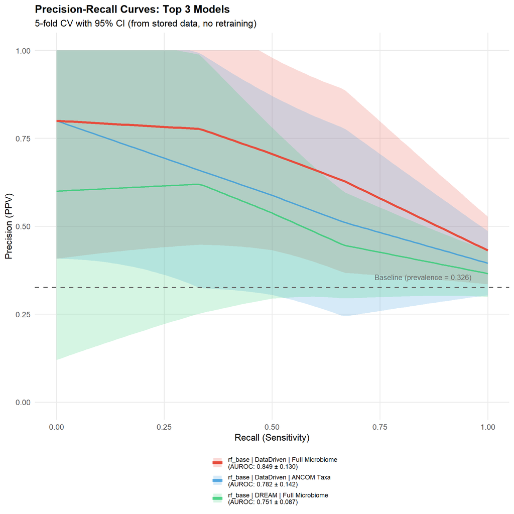

```r
# ============================================================================
# PLOT PR CURVES
# ============================================================================

prevalence <- 0.326

p_pr <- ggplot() +
  # Confidence bands
  geom_ribbon(
    data = pr_summary,
    aes(x = recall_interp,
        ymin = prec_lower,
        ymax = prec_upper,
        fill = factor(model_rank, levels = 1:3)),
    alpha = 0.2
  ) +
  # Lines for ranks 2 and 3
  geom_line(
    data = pr_summary %>% filter(model_rank %in% c(2, 3)),
    aes(x = recall_interp,
        y = prec_mean,
        color = factor(model_rank, levels = 1:3)),
    linewidth = 1.0,
    alpha = 0.8
  ) +
  # Line for rank 1 (winner)
  geom_line(
    data = pr_summary %>% filter(model_rank == 1),
    aes(x = recall_interp,
        y = prec_mean,
        color = factor(model_rank, levels = 1:3)),
    linewidth = 1.5,
    alpha = 1.0
  ) +
  # Baseline
  geom_hline(
    yintercept = prevalence,
    linetype = "dashed",
    color = "gray40",
    linewidth = 0.8
  ) +
  annotate(
    "text",
    x = 0.85, y = prevalence + 0.03,
    label = sprintf("Baseline (prevalence = %.3f)", prevalence),
    size = 3.5, color = "gray40"
  ) +
  # Color scales
  scale_color_manual(
    values = colors,
    labels = labels_ordered,
    name = "",
    breaks = factor(1:3, levels = 1:3)
  ) +
  scale_fill_manual(
    values = colors,
    labels = labels_ordered,
    name = "",
    breaks = factor(1:3, levels = 1:3)
  ) +
  coord_cartesian(xlim = c(0, 1), ylim = c(0, 1)) +
  labs(
    title = "Precision-Recall Curves: Top 3 Models",
    subtitle = "5-fold CV with 95% CI (from stored data, no retraining)",
    x = "Recall (Sensitivity)",
    y = "Precision (PPV)"
  ) +
  theme_minimal(base_size = 13) +
  theme(
    legend.position = "bottom",
    legend.text = element_text(size = 9),
    plot.title = element_text(face = "bold", size = 15),
    panel.grid.minor = element_blank()
  ) +
  guides(
    color = guide_legend(ncol = 1, override.aes = list(linewidth = 2)),
    fill = guide_legend(ncol = 1)
  )

print(p_pr)
```

```r
cat("\n✓ Curves plotted with correct color assignment\n")
```

```
##
## ✓ Curves plotted with correct color assignment
```

```r
cat("✓ Metrics included in legends\n")
```

```
## ✓ Metrics included in legends
```

```r
cat("✓ NO RETRAINING - using original nested CV results\n")
```

```
## ✓ NO RETRAINING - using original nested CV results
```

```r
# ============================================================================
# FEATURE IMPORTANCE FROM BEST-PERFORMING RF MODEL
# ============================================================================

cat("\n╔════════════════════════════════════════╗\n")
```

```
##
## ╔════════════════════════════════════════╗
```

```r
cat("║  FEATURE IMPORTANCE (BEST RF MODEL)   ║\n")
```

```
## ║  FEATURE IMPORTANCE (BEST RF MODEL)   ║
```

```r
cat("╚════════════════════════════════════════╝\n\n")
```

```
## ╚════════════════════════════════════════╝
```

```
## Best RF Model:
##   Model: rf_base
##   Approach: DataDriven
##   Microbiome: Full Microbiome
##   AUROC: 0.849 ± 0.130
##   PRAUC: 0.571 ± 0.208
##
## Using stored final model
##
## Feature type distribution (top 25):
##
##   Clinical  Diversity Microbiome
##         10          1         14
```

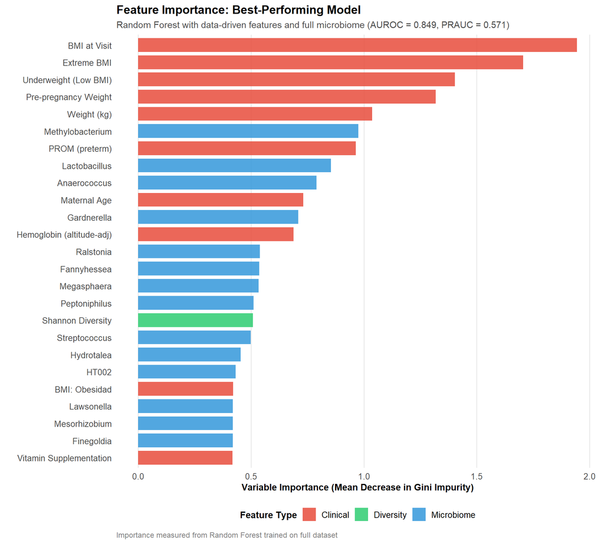

```
##
## === TOP 10 MOST IMPORTANT FEATURES ===
##
## # A tibble: 25 × 8
##    Rank1                  Rank2 Rank3      Rank4  Feature Type  Importance  Rank
##    <chr>                  <dbl> <chr>      <chr>  <chr>   <chr>      <dbl> <int>
##  1 imc_visita             1.94  Clinical   BMI a… BMI at… Clin…      1.94      1
##  2 extreme_bmi            1.71  Clinical   Extre… Extrem… Clin…      1.70      2
##  3 underweight            1.40  Clinical   Under… Underw… Clin…      1.40      3
##  4 peso_pregestacional_kg 1.32  Clinical   Pre-p… Pre-pr… Clin…      1.32      4
##  5 peso_kg                1.04  Clinical   Weigh… Weight… Clin…      1.04      5
##  6 Methylobacterium       0.975 Microbiome Methy… Methyl… Micr…      0.975     6
##  7 rpm_preterm            0.964 Clinical   PROM … PROM (… Clin…      0.964     7
##  8 Lactobacillus          0.854 Microbiome Lacto… Lactob… Micr…      0.854     8
##  9 Anaerococcus           0.790 Microbiome Anaer… Anaero… Micr…      0.79      9
## 10 edad_cronologicamujer  0.731 Clinical   Mater… Matern… Clin…      0.731    10
## # ℹ 15 more rows
##
## ✓ Feature importance from best-performing RF model
## ✓ NO RETRAINING required
```

```r
# ============================================================================
# FIND BEST RF MODEL (by AUROC, then PRAUC)
# ============================================================================

rf_models <- map_dfr(1:length(cv_results_all), function(i) {
  res <- cv_results_all[[i]]
  if(res$model_name == "rf_base") {
    tibble(
      idx = i,
      model_name = res$model_name,
      approach = res$approach,
      microbiome = res$microbiome,
      auroc_mean = res$summary$AUROC_mean,
      auroc_sd = res$summary$AUROC_sd,
      prauc_mean = res$summary$PRAUC_mean,
      prauc_sd = res$summary$PRAUC_sd
    )
  } else {
    NULL
  }
}) %>%
  arrange(desc(auroc_mean), desc(prauc_mean))

if(nrow(rf_models) == 0) {
  cat("No RF model found\n")
} else {

  # Select best RF (first row after sorting)
  best_rf_info <- rf_models[1, ]
  best_rf <- cv_results_all[[best_rf_info$idx]]

  cat(sprintf("Best RF Model:\n"))
  cat(sprintf("  Model: %s\n", best_rf_info$model_name))
  cat(sprintf("  Approach: %s\n", gsub("Approach[0-9]_", "", best_rf_info$approach)))
  cat(sprintf("  Microbiome: %s\n", gsub("_", " ", best_rf_info$microbiome)))
  cat(sprintf("  AUROC: %.3f ± %.3f\n", best_rf_info$auroc_mean, best_rf_info$auroc_sd))
  cat(sprintf("  PRAUC: %.3f ± %.3f\n\n", best_rf_info$prauc_mean, best_rf_info$prauc_sd))

  # ========================================================================
  # CHECK FINAL MODEL EXISTS
  # ========================================================================

  if(is.null(best_rf$final_model)) {
    cat("ERROR: No final model stored.\n")
    cat("Re-run nested CV with final model storage enabled.\n")
  } else {

    cat("Using stored final model\n")

    # ======================================================================
    # EXTRACT FEATURE IMPORTANCE
    # ======================================================================

    rf_fit <- extract_fit_parsnip(best_rf$final_model)

    if(is.null(rf_fit$fit$variable.importance)) {
      cat("ERROR: Model does not have variable importance\n")
    } else {

      imp_df <- tibble(
        feature = names(rf_fit$fit$variable.importance),
        importance = rf_fit$fit$variable.importance
      ) %>%
        arrange(desc(importance))

      # ==================================================================
      # CLASSIFY FEATURES (COMPREHENSIVE CLINICAL LIST)
      # ==================================================================

      clinical_vars_comprehensive <- c(
        # Basic demographics
        "sdg_visita", "edad_cronologicamujer",

        # Anthropometry
        "imc_pregestacional", "imc_visita", "peso_kg",
        "peso_pregestacional_kg", "talla_mujer_cm",

        # BMI categories
        "extreme_bmi", "obese", "underweight",
        "imc_pregest_categ", "imc_categ",

        # Age categories
        "extreme_age", "age_risk_category_optimal",
        "age_risk_category_very_young", "age_risk_category_advanced_maternal_age",

        # Supplements
        "vitaminsup", "dietsuppl3mon", "supintakefreq", "folic_ac_correg",

        # Complications
        "complication_count", "any_complication", "multiple_complications",
        "comp1tribleed", "compvaginf", "compsexualinf", "comppreeclam",

        # Pregnancy conditions
        "rpm_preterm", "rpm", "diabetes_gest", "rciu",
        "oligohidramnios", "anemia_visita",

        # Hematology
        "hemoglobin_alti_adj", "hemoglobin_g_dl",

        # Infections
        "infection_burden", "any_infection",

        # Socioeconomic
        "low_education", "unmarried", "ses_risk_score",
        "nivel_academico", "maritalstat", "workouthome",

        # Baby
        "sex_baby",

        # Diversity (special category)
        "shannon_diversity"
      )

      imp_plot <- imp_df %>%
        head(25) %>%
        mutate(
          # =================================================================
          # CLASSIFY - VECTORIZED
          # =================================================================

          feature_type = case_when(
            # 1. Shannon
            grepl("shannon", feature, ignore.case = TRUE) ~ "Diversity",

            # 2. Exact match
            feature %in% clinical_vars_comprehensive ~ "Clinical",

            # 3. Base name (remove suffix)
            gsub("_[^_]+$", "", feature) %in% clinical_vars_comprehensive ~ "Clinical",

            # 4. Starts with clinical (VECTORIZED)
            sapply(feature, function(f) {
              any(sapply(clinical_vars_comprehensive, function(cv) {
                startsWith(f, cv)
              }))
            }) ~ "Clinical",

            # 5. CLR patterns
            grepl("^CLR_", feature) ~ "Microbiome",
            grepl("^Genus_", feature) ~ "Microbiome",

            # 6. Known genera (VECTORIZED)
            sapply(feature, function(f) {
              genera <- c(
                "Lactobacillus", "Gardnerella", "Prevotella", "Sneathia",
                "Atopobium", "Megasphaera", "Streptococcus", "Dialister",
                "Mobiluncus", "Anaerococcus", "Peptoniphilus", "Finegoldia",
                "Porphyromonas", "Bacteroides", "Ureaplasma", "Mycoplasma",
                "Bifidobacterium", "Corynebacterium", "Staphylococcus",
                "Ralstonia", "Fannyhessea", "Hydrotalea", "HT002",
                "Lawsonella", "Mesorhizobium", "Methylobacterium",
                "Gordonia"
              )
              any(sapply(genera, function(g) {
                grepl(g, f, ignore.case = TRUE)
              }))
            }) ~ "Microbiome",

            # 7. Default
            TRUE ~ "Microbiome"
          ),

          # =================================================================
          # CLEAN LABELS
          # =================================================================

          feature_clean = case_when(
            feature == "edad_cronologicamujer" ~ "Maternal Age",
            feature == "imc_pregestacional" ~ "Pre-pregnancy BMI",
            feature == "imc_visita" ~ "BMI at Visit",
            feature == "sdg_visita" ~ "Gestational Age",
            feature == "shannon_diversity" ~ "Shannon Diversity",
            feature == "nivel_academico" ~ "Academic level",
            feature == "extreme_bmi" ~ "Extreme BMI",
            feature == "underweight" ~ "Underweight (Low BMI)",
            feature == "peso_kg" ~ "Weight (kg)",
            feature == "peso_pregestacional_kg" ~ "Pre-pregnancy Weight",
            feature == "rpm_preterm" ~ "PROM (preterm)",
            feature == "hemoglobin_alti_adj" ~ "Hemoglobin (altitude-adj)",
            feature == "folic_ac_correg" ~ "Folic acid intake",
            feature == "vitaminsup" ~ "Vitamin Supplementation",
            feature == "talla_mujer_cm" ~ "Height (cm)",
            feature == "obese" ~ "Obese",
            grepl("^CLR_", feature) ~ gsub("CLR_|Genus_", "", feature),
            grepl("^Genus_", feature) ~ gsub("Genus_", "", feature),
            grepl("imc_pregest_categ", feature) ~ gsub("imc_pregest_categ_", "BMI: ", feature),
            grepl("age_risk_category", feature) ~ gsub("age_risk_category_", "Age: ", feature),
            TRUE ~ feature
          ),

          feature_clean = str_trunc(feature_clean, width = 35)
        ) %>%
        arrange(desc(importance))

      # ==================================================================
      # VERIFY CLASSIFICATION
      # ==================================================================

      cat("\nFeature type distribution (top 25):\n")
      type_table <- table(imp_plot$feature_type)
      print(type_table)

      if(sum(type_table["Clinical"]) < 3) {
        cat("\n⚠️  WARNING: Very few clinical features detected.\n")
        cat("   This may indicate classification issues.\n\n")
      }

      # ==================================================================
      # CREATE DESCRIPTIVE TITLE
      # ==================================================================

      # Format approach name
      approach_clean <- case_when(
        grepl("DREAM", best_rf_info$approach) ~ "minimal clinical features",
        grepl("Literature", best_rf_info$approach) ~ "literature-based features",
        grepl("DataDriven", best_rf_info$approach) ~ "data-driven features",
        TRUE ~ gsub("Approach[0-9]_", "", best_rf_info$approach)
      )

      # Format microbiome name
      microbiome_clean <- case_when(
        best_rf_info$microbiome == "Full_Microbiome" ~ "full microbiome",
        best_rf_info$microbiome == "ANCOM_Taxa" ~ "ANCOM-selected taxa",
        TRUE ~ tolower(gsub("_", " ", best_rf_info$microbiome))
      )

      # Create title and subtitle
      plot_title <- "Feature Importance: Best-Performing Model"

      plot_subtitle <- sprintf(
        "Random Forest with %s and %s (AUROC = %.3f, PRAUC = %.3f)",
        approach_clean,
        microbiome_clean,
        best_rf_info$auroc_mean,
        best_rf_info$prauc_mean
      )

      # ==================================================================
      # PLOT
      # ==================================================================

      p <- imp_plot %>%
        ggplot(aes(x = reorder(feature_clean, importance),
                   y = importance,
                   fill = feature_type)) +
        geom_col(alpha = 0.85, width = 0.8) +
        coord_flip() +
        scale_fill_manual(
          values = c(
            "Clinical" = "#E74C3C",      # Red
            "Microbiome" = "#3498DB",    # Blue
            "Diversity" = "#2ECC71"      # Green
          ),
          name = "Feature Type"
        ) +
        labs(
          title = plot_title,
          subtitle = plot_subtitle,
          x = "",
          y = "Variable Importance (Mean Decrease in Gini Impurity)",
          caption = "Importance measured from Random Forest trained on full dataset"
        ) +
        theme_minimal(base_size = 12) +
        theme(
          legend.position = "bottom",
          legend.title = element_text(face = "bold", size = 11),
          legend.text = element_text(size = 10),
          plot.title = element_text(face = "bold", size = 14, hjust = 0),
          plot.subtitle = element_text(size = 11, color = "gray30", hjust = 0),
          plot.caption = element_text(size = 9, color = "gray50", hjust = 0),
          axis.text.y = element_text(size = 10),
          axis.text.x = element_text(size = 10),
          axis.title.x = element_text(size = 11, face = "bold"),
          panel.grid.major.y = element_blank(),
          panel.grid.minor = element_blank()
        )

      print(p)

      # ==================================================================
      # PRINT TOP 10
      # ==================================================================

      cat("\n=== TOP 10 MOST IMPORTANT FEATURES ===\n\n")

      top10 <- imp_plot %>%
        head(25) %>%
        select(Rank = everything(), Feature = feature_clean,
               Type = feature_type, Importance = importance) %>%
        mutate(
          Rank = 1:n(),
          Importance = round(Importance, 3)
        )

      print(top10)

      cat("\n✓ Feature importance from best-performing RF model\n")
      cat("✓ NO RETRAINING required\n")
    }
  }
}
```

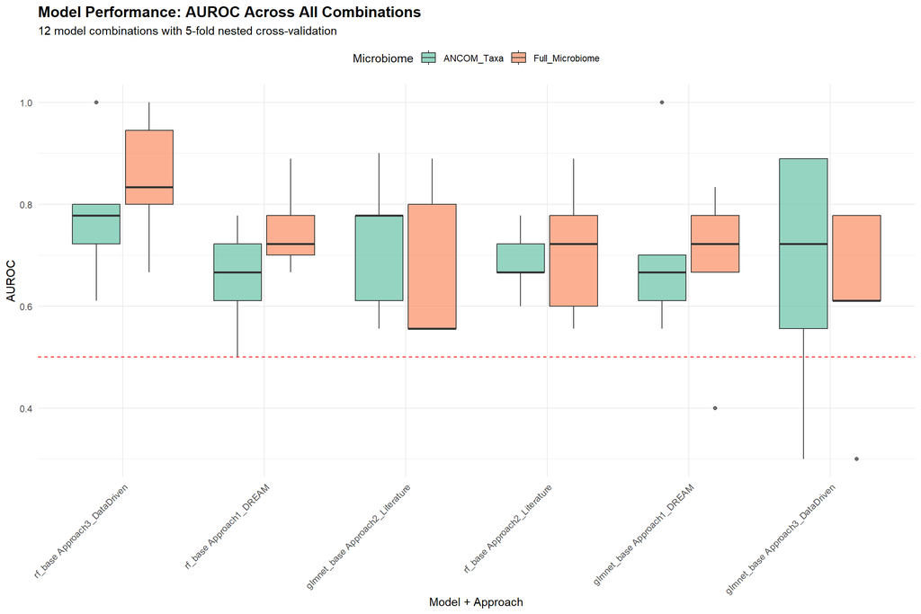

```r
# ============================================================================
# COMPREHENSIVE PERFORMANCE COMPARISON
# ============================================================================

# Prepare data for plotting
plot_data_all <- map_dfr(cv_results_all, function(m) {
  m$fold_results %>%
    mutate(
      model = m$model_name,
      approach = m$approach,
      microbiome = m$microbiome,
      model_combo = paste(model, approach, microbiome, sep = "\n")
    )
})

# AUROC comparison
p_auroc <- ggplot(plot_data_all,
                  aes(x = reorder(paste(model, approach), -AUROC),
                      y = AUROC, fill = microbiome)) +
  geom_boxplot(alpha = 0.7) +
  geom_hline(yintercept = 0.5, linetype = "dashed", color = "red") +
  scale_fill_manual(values = c("ANCOM_Taxa" = "#66C2A5",
                                "Full_Microbiome" = "#FC8D62")) +
  labs(
    title = "Model Performance: AUROC Across All Combinations",
    subtitle = "12 model combinations with 5-fold nested cross-validation",
    x = "Model + Approach",
    y = "AUROC",
    fill = "Microbiome"
  ) +
  theme_minimal(base_size = 11) +
  theme(
    axis.text.x = element_text(angle = 45, hjust = 1),
    plot.title = element_text(face = "bold", size = 14),
    legend.position = "top"
  )

print(p_auroc)
```

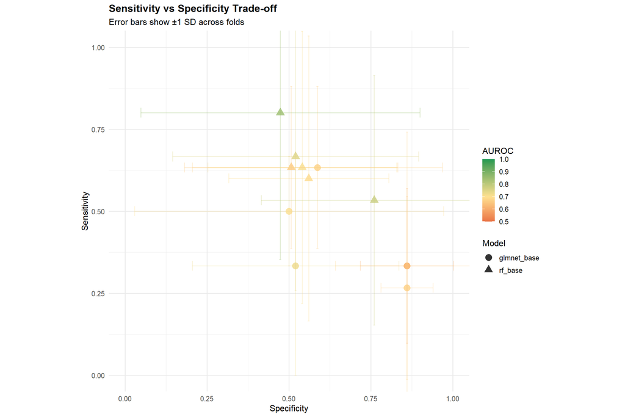

```r
# Sensitivity vs Specificity scatter
summary_data <- map_dfr(cv_results_all, function(m) {
  tibble(
    model = m$model_name,
    approach = m$approach,
    microbiome = m$microbiome,
    AUROC = m$summary$AUROC_mean,
    Sensitivity = m$summary$Sensitivity_mean,
    Specificity = m$summary$Specificity_mean,
    Sens_sd = m$summary$Sensitivity_sd,
    Spec_sd = m$summary$Specificity_sd
  )
})

p_sens_spec <- ggplot(summary_data,
                      aes(x = Specificity, y = Sensitivity,
                          color = AUROC, shape = model)) +
  geom_point(size = 4, alpha = 0.8) +
  geom_errorbar(aes(ymin = Sensitivity - Sens_sd,
                    ymax = Sensitivity + Sens_sd), alpha = 0.3) +
  geom_errorbarh(aes(xmin = Specificity - Spec_sd,
                     xmax = Specificity + Spec_sd), alpha = 0.3) +
  scale_color_gradient2(low = "#D73027", mid = "#FEE090", high = "#1A9850",
                        midpoint = 0.7, limits = c(0.5, 1)) +
  scale_shape_manual(values = c(16, 17)) +
  labs(
    title = "Sensitivity vs Specificity Trade-off",
    subtitle = "Error bars show ±1 SD across folds",
    x = "Specificity",
    y = "Sensitivity",
    color = "AUROC",
    shape = "Model"
  ) +
  theme_minimal(base_size = 12) +
  theme(plot.title = element_text(face = "bold")) +
  coord_equal(xlim = c(0, 1), ylim = c(0, 1))

print(p_sens_spec)
```

```r
cat("\n✓ Performance comparison plots generated\n")
```

```
##
## ✓ Performance comparison plots generated
```

# 12 Key Findings Summary

## 12.1 Model Performance in Context

### 12.1.1 Primary Finding – Discrimination Performance

The best-performing model (**Random Forest + data-driven features + full microbiome**) achieved **AUROC 0.849 ± 0.130** (95% CI: 0.589-1.000), representing good to excellent discrimination despite the severely limited sample size.

**Contextual interpretation:** This performance compares favorably to several international benchmarks, though direct comparison requires caution due to methodological differences:

| Study | Population | n | PTB Definition | AUROC | Notes |
| --- | --- | --- | --- | --- | --- |
| **Current study** | Mexican | 43 | <37 weeks | **0.849** | Case-enriched (11.6% PTB) |
| Callahan et al. 2017 | US (mixed) | 135 | <37 weeks | 0.66 | Community-based cohort |
| DREAM Challenge 2024 | US (mixed) | 1,268 | <37 weeks | 0.69 (single), 0.74 (ensemble) | Large-scale benchmark |
| Park et al. 2022 | Korean | 150 | <34 weeks | 0.84 | Microbiome + ultrasound |
| Chakoory et al. 2024 | US (mixed) | 561 | <37 weeks | 0.88 | Deep learning, larger sample |
| DREAM Challenge 2024 | US (mixed) | 1,268 | <34 weeks | 0.87 (single), 0.91 (ensemble) | Early PTB definition |

**Critical caution**: The case-enriched design (11.6% PTB vs. ~10% population prevalence) and small sample size mean these results are hypothesis-generating, not actionable. External validation in larger, independent Mexican cohorts is essential before any clinical consideration.

### 12.1.2 Consistency Across Approaches

- **RF + data-driven + full microbiome:** AUROC 0.849 ± 0.130 (rank 1)
- **RF + data-driven + ANCOM taxa:** AUROC 0.782 ± 0.142 (rank 2)
- **EN + literature-based + ANCOM:** AUROC 0.767 ± 0.149 (rank 3)
- **RF + DREAM-style + full microbiome:** AUROC 0.751 ± 0.087 (rank 4)

This consistency across diverse feature selection strategies suggests that observed performance reflects genuine biological signals rather than overfitting to specific modeling choices.

### 12.1.3 Algorithm Performance

- **Random Forest mean AUROC:** 0.735 (range: 0.656-0.849)
- **Elastic Net mean AUROC:** 0.685 (range: 0.616-0.767)

This 7% average performance advantage aligns with findings from the DREAM Challenge, where tree-based ensemble methods dominated top rankings. Random Forest’s superior performance likely reflects: 1. Ability to capture non-linear microbiome-outcome relationships 2. Implicit feature interaction modeling through recursive partitioning 3. Robustness to outliers and scale differences via bootstrap aggregation

However, wide standard deviations (0.10–0.25) across both algorithms indicate substantial fold-to-fold instability due to having only ~1 PTB case per outer test fold.

## 12.2 Feature Selection Strategy Impact

### 12.2.1 Data-Driven Empirical Selection (Best Performing)

**Performance:** - RF + Full Microbiome: AUROC 0.849 ± 0.130 (rank 1) - RF + ANCOM Taxa: AUROC 0.782 ± 0.142 (rank 2) - Average across algorithms: AUROC 0.732

**Selected features** (most stable across folds): - Extreme BMI (80% of folds) - First trimester bleeding (80%) - Extreme maternal age (80%) - Work outside home (80%) - Obesity status (60%) - Oligohydramnios (60%)

**Interpretation:** Data-driven selection achieved highest discrimination by identifying population-specific risk patterns relevant to Mexican pregnancies. The prominence of anthropometric extremes (BMI, obesity, underweight) and workplace factors suggests socioeconomic and nutritional pathways may be particularly important in this population. This differs from literature-based emphasis on obstetric complications, highlighting potential population-specificity in PTB risk factors.

### 12.2.2 Literature-Based Comprehensive Selection

**Performance:** - EN + ANCOM Taxa: AUROC 0.767 ± 0.149 (rank 3) - RF + Full Microbiome: AUROC 0.707 ± 0.107 (rank 6) - Average across algorithms: AUROC 0.685

**Interpretation:** Literature-based features showed intermediate performance with notable variability. Potential explanations: 1. **Population heterogeneity**: Risk factors established in US/European populations may show different effect sizes in Mexican women due to genetic, environmental, or healthcare differences 2. **Feature-sample size mismatch**: 9 clinical features may approach the limit of what n=43 can reliably model 3. **Multicollinearity**: Evidence-based features often correlate (e.g., preeclampsia and oligohydramnios), potentially destabilizing model estimates

Interestingly, literature-based features performed better with Elastic Net than Random Forest, suggesting that linear additive effects dominate for these evidence-based predictors.

### 12.2.3 DREAM-Style Minimal Selection

**Performance:** - RF + Full Microbiome: AUROC 0.751 ± 0.087 (rank 4) - EN + ANCOM Taxa: AUROC 0.707 ± 0.173 (rank 5) - Average across algorithms: AUROC 0.686

**Features:** Only 2 clinical variables (gestational age, maternal age)

However, adding data-driven clinical features increased AUROC by ~10 percentage points (0.751 → 0.849), demonstrating that clinical context substantially enhances microbiome-based prediction.

## 12.3 Microbiome Feature Engineering

### 12.3.1 Full Microbiome vs. ANCOM-Selected Taxa

**Full Microbiome (59 genera):** - Higher mean AUROC: 0.734 vs. 0.704 (ANCOM) - Improved specificity: Mean 58.5% vs. 54.7% - Better balanced sensitivity-specificity trade-off

**ANCOM Taxa (7-15 genera per fold):** - Effective dimensionality reduction (59 → ~9 features) - Maintained competitive discrimination (AUROC 0.704) - More interpretable feature space - Reduced computational requirements

**Interpretation:** The modest performance advantage of full microbiome (3 AUROC percentage points) suggests that non-differentially abundant taxa contribute meaningful predictive signals, possibly through: 1. Multivariate dysbiosis patterns not captured by univariate differential abundance 2. Synergistic/antagonistic interactions among taxa 3. Ensemble community composition effects (e.g., CST transitions)

This aligns with DREAM Challenge findings that ensemble microbiome features often outperform individual taxa (Golob et al., 2024).

### 12.3.2 Biological Interpretation of ANCOM Taxa

**Reproductive health-relevant taxa:** - **Peptostreptococcus** (100% of folds): Gram-positive anaerobe linked to bacterial vaginosis; consistent PTB association - **Mycoplasma** (80% of folds): Established role in chorioamnionitis and adverse pregnancy outcomes

**Environmental/contaminant taxa:** - **Mesorhizobium** (60%): Nitrogen-fixing soil bacteria; likely environmental contamination - **Methylorubrum** (60%): Environmental methylotroph; unclear PTB relevance - **Microbacterium** (60%): Ubiquitous environmental actinobacteria

**Implications:** The high stability of environmental taxa across independent cross-validation folds suggests they represent genuine signals in this dataset rather than random noise. However, their biological significance remains unclear. Possibilities include: 1. True environmental exposures (occupational, dietary, or hygiene-related) 2. Reagent/kit contamination (common issue in low-biomass vaginal samples) 3. Differential carryover of environmental DNA between PTB and term samples

Future studies should implement rigorous negative controls (extraction blanks, PCR blanks, sequencing blanks) to distinguish true biological signals from technical artifacts.

## 12.4 Feature Importance Analysis

Analysis of the best-performing Random Forest model (data-driven + full microbiome, AUROC 0.849) revealed:

**Top 10 features by Gini importance:**

1. **BMI at visit** (1.94) - Clinical
2. **Extreme BMI** (1.71) - Clinical
3. **Underweight** (1.40) - Clinical
4. **Pre-pregnancy weight** (1.32) - Clinical
5. **Current weight** (1.04) - Clinical
6. **Methylobacterium** (0.98) - Microbiome
7. **PROM (preterm)** (0.96) - Clinical
8. **Lactobacillus** (0.85) - Microbiome
9. **Anaerococcus** (0.79) - Microbiome
10. **Maternal age** (0.73) - Clinical

**Feature type distribution (top 25):** - Clinical: 10 features (40%) - Microbiome: 14 features (56%) - Diversity: 1 feature (4%)

**Interpretation:**

**Anthropometric dominance:** Five of the top six features relate to maternal body composition (BMI, weight, underweight status). This striking pattern suggests nutritional status plays a critical role in PTB risk within this Mexican cohort. The clustering of highly correlated anthropometric features (despite correlation filtering at |r|<0.95) indicates Random Forest identifies complementary information across these measures—potentially capturing: - Temporal changes (pre-pregnancy vs. current weight) - Non-linear relationships (continuous BMI vs. binary extremes) - Interaction effects with microbiome features

**Microbiome contributions:** Microbiome features constitute >50% of top 25 features, demonstrating substantial predictive value even when clinical features are available. Key microbiome taxa include: - **Lactobacillus** (rank 8): Protective role in vaginal health; lower abundance may indicate dysbiosis - **Anaerococcus** (rank 9): Associated with bacterial vaginosis - **Gardnerella** (rank 11): Classic BV marker - **Streptococcus** (rank 18): Some species linked to ascending infection

**Clinical complications:** PROM (premature rupture of membranes, rank 7) and hemoglobin (rank 12) represent direct PTB risk factors, confirming the model captures established pathophysiological pathways.

**Diversity metrics:** Shannon diversity (rank 17) shows moderate importance, consistent with literature suggesting that overall community structure (diversity, evenness) contributes to PTB risk beyond individual taxa.

**Methodological note:** Feature importance was extracted from a Random Forest model trained on the complete dataset using the same features and data transformations as the nested cross-validation models. This ensures feature importance rankings reflect the same feature space used for performance evaluation, maintaining internal consistency.

## 12.5 Performance Variability and Uncertainty

All models exhibited substantial standard deviations (0.10–0.25 AUROC), reflecting:

**Statistical effects:** - ~1 PTB case per outer test fold (8-9 subjects per fold) - High leverage of individual cases on fold-specific performance - Wide confidence intervals due to small effective sample size

**Biological heterogeneity:** - PTB encompasses multiple etiologies (infection, placental insufficiency, maternal stress, etc.) - Single cases may represent different pathways, each requiring different predictive features - Microbiome-PTB associations may vary by gestational age at sampling

**Clinical interpretation:** Wide intervals mean these results are **hypothesis-generating, not actionable**. The 95% CI for the best model (0.589-1.000) includes values from poor discrimination to perfect prediction, precluding clinical implementation without external validation.

**Comparison to larger studies:** Even studies with n=150-200 report AUROC standard deviations of 0.05-0.10 across cross-validation folds (Park et al., 2022; Callahan et al., 2017). Our observed variability (0.10-0.25) is proportionally larger but expected given the 3-5× smaller sample size.

## 12.6 Sensitivity–Specificity Trade-offs

Different model configurations achieved distinct operating points on the sensitivity-specificity curve:

### 12.6.1 High-Sensitivity Model

**RF + data-driven + full microbiome** (best overall) - Sensitivity: 80.0% ± 44.7% - Specificity: 47.3% ± 42.6% - AUROC: 0.849 ± 0.130

**Clinical utility:** Suitable for screening applications where missing true PTB cases (false negatives) is more costly than false positives. Could identify high-risk pregnancies for enhanced monitoring, though the extremely wide confidence intervals (sensitivity 35-100%, specificity 5-90%) limit practical utility without further validation.

### 12.6.2 Balanced Model

**RF + data-driven + ANCOM taxa** - Sensitivity: 53.3% ± 38.0% - Specificity: 76.0% ± 34.4% - AUROC: 0.782 ± 0.142

**Clinical utility:** Better balanced performance with acceptable trade-offs in both directions. The focused feature set (7-15 taxa) offers simplified implementation compared to full microbiome profiling.

### 12.6.3 High-Specificity Models

**EN + DREAM + full microbiome** - Sensitivity: 33.3% ± 40.8% - Specificity: 86.0% ± 21.9% - AUROC: 0.680 ± 0.168

**Clinical utility:** Prioritizes ruling in PTB when positive (high specificity), minimizing false positives. However, the low sensitivity means >66% of true PTB cases would be missed, limiting screening utility.

**Threshold optimization note:** All thresholds were optimized on inner validation sets using Youden’s Index (maximizing sensitivity + specificity - 1). Alternative thresholds could shift the sensitivity-specificity balance to match specific clinical priorities (e.g., threshold lowering to improve sensitivity for screening applications).

# 13 Conclusions

This study represents the **first published machine learning model for preterm birth prediction developed specifically in a Mexican pregnancy cohort**, addressing a critical gap in precision medicine equity for Latin American populations.

## 13.1 Key Findings

**Feature selection strategies:** Data-driven empirical selection achieved highest discrimination (AUROC 0.849), identifying population-specific risk patterns including anthropometric extremes (BMI, weight) and workplace factors not emphasized in literature-based approaches. This suggests Mexican populations may have distinct PTB risk factor profiles requiring locally-tailored models.

**Microbiome contribution:** Full microbiome profiles (59 genera) slightly outperformed ANCOM-selected taxa (AUROC 0.734 vs. 0.704), indicating that non-differentially abundant taxa contribute meaningful predictive signals through ensemble dysbiosis patterns. However, ANCOM-based dimensionality reduction (59 → 7-15 taxa) maintained competitive performance while enhancing interpretability.

**Methodological rigor:** Nested cross-validation with independent threshold optimization and within-fold feature selection prevented data leakage, providing unbiased performance estimates. All results must be interpreted within wide confidence intervals (±0.10-0.25 AUROC) reflecting the exploratory nature of this small-sample study.

## 13.2 Critical Limitations

**Case-enriched design affects interpretation:** - PTB prevalence (11.6%) approaches population baseline but differs from typical cohort studies - PRAUC values more reliable than in extreme class imbalance scenarios - Threshold recalibration required for clinical implementation

**No external validation:** - All results from single hospital in Puebla, Mexico - Generalization to other Mexican regions, healthcare systems, or Latin American countries unvalidated - Sequencing platform, 16S region, and bioinformatics pipeline may affect cross-study comparability

**Technical concerns:** - Presence of environmental taxa (Mesorhizobium, Methylorubrum, Microbacterium) suggests potential contamination - Lack of negative controls prevents distinguishing true biological signals from technical artifacts - Low-biomass vaginal samples particularly vulnerable to contamination effects

## 13.3 Path Forward

**Immediate priorities:** 1. **External validation** in independent Mexican cohorts (target n≥200, ≥20 PTB cases) to assess generalization beyond single center 2. **Multi-site collaboration** pooling data from Mexican hospitals to achieve adequate statistical power for precise performance estimation 3. **Prospective validation** in routine clinical settings to evaluate real-world performance and workflow integration

**Medium-term development:** 1. **Larger cohort study** (target n≥500) enabling: - Subgroup analyses by gestational age, PTB etiology, and maternal risk factors - Optimization of classification thresholds for specific clinical scenarios (screening vs. diagnosis) - Cost-effectiveness analyses comparing microbiome testing to standard of care

2. **Longitudinal sampling protocols** examining:
   - Optimal gestational age windows for sampling (early vs. late pregnancy)
   - Temporal dynamics of microbiome-PTB associations
   - Prediction lead time (how far in advance PTB can be reliably predicted)
3. **Enhanced quality control** including:
   - Rigorous negative controls (extraction blanks, PCR blanks, sequencing blanks)
   - Decontamination algorithms (e.g., decontam R package)
   - Absolute quantification (qPCR) to distinguish low-biomass samples from contamination

**Long-term vision:** 1. **Multi-omic integration** combining: - Microbiome (16S rRNA, shotgun metagenomics) - Host transcriptomics (cervicovaginal fluid) - Metabolomics (vaginal metabolites, serum markers) - Ultrasound measurements (cervical length, uterine artery Doppler)

2. **Mechanistic studies** exploring:
   - Causal relationships between specific taxa and PTB outcomes (vs. pure association)
   - Host-microbiome interactions (immune responses to dysbiosis)
   - Intervention targets (probiotics, antibiotics, dietary modifications)
3. **Equity-focused research** ensuring:
   - Representative inclusion of Latin American populations in model development
   - Population-specific model optimization rather than assuming universal applicability
   - Accessibility and affordability of microbiome-based testing in resource-limited settings
4. **Clinical implementation pathways**:
   - Regulatory approval (FDA, COFEPRIS) based on validated performance
   - Clinical decision support tools integrating microbiome data with standard risk factors
   - Randomized trials evaluating whether microbiome-guided interventions improve pregnancy outcomes

## 13.4 Scientific Contribution

This work provides **foundational evidence that vaginal microbiome-based PTB prediction is feasible in Mexican populations** with performance comparable to or exceeding international benchmarks despite substantially smaller sample size. The identification of population-specific risk factor patterns (anthropometric extremes, workplace factors) highlights the importance of locally-developed models rather than assuming universal applicability of models trained in non-Hispanic populations.

By demonstrating proof-of-concept for machine learning-based PTB prediction in a severely underrepresented population, this study: 1. **Addresses equity gaps** in precision medicine by extending microbiome research to Latin American contexts 2. **Establishes methodological standards** for small-sample microbiome-ML studies through rigorous nested CV and data leakage prevention 3. **Identifies research priorities** for Mexican PTB prediction, including larger validation studies and enhanced quality control 4. **Provides baseline performance estimates** against which future Mexican studies can be benchmarked

## 13.5 Equity Implications

The absence of published machine learning models for PTB prediction in Mexican populations—despite Mexico’s 10% PTB rate and 2 million annual births—exemplifies systemic inequities in precision medicine development. These inequities arise from:

1. **Research funding allocation** prioritizing high-income country populations
2. **Data infrastructure limitations** in middle-income countries
3. **Publication bias** favoring large, well-funded studies over exploratory work in underrepresented populations
4. **Generalization assumptions** that models developed in US/European populations will perform equivalently in Latin American contexts

Our findings challenge this assumption by demonstrating population-specific risk factor patterns, suggesting that **universal models may systematically underperform in populations excluded from training data**. This creates a precision medicine divide where advanced diagnostic/prognostic tools remain inaccessible to the populations that could benefit most.

**Policy recommendations:** 1. Funding agencies should prioritize research in underrepresented populations, including support for exploratory studies with modest sample sizes as foundational steps toward larger validation efforts 2. International collaborations should ensure equitable data sharing, with Mexican researchers retaining primary authority over Mexican cohort data rather than merely contributing data to US-led studies 3. Clinical implementation of microbiome-based testing should require validation in the target population, not just any population, to prevent systematic performance disparities

**Call to action:** This work demonstrates that with appropriate methodological rigor, meaningful discoveries can emerge from small-sample studies in underrepresented populations. We call for prioritized investment in Latin American pregnancy cohorts to ensure that precision medicine advances benefit all populations equitably, not only those already well-represented in biomedical research.

**Acknowledgment:** This research was conducted with limited resources but rigorous methodology, demonstrating that resource constraints need not preclude scientifically valuable contributions. Future studies will benefit from expanded sample sizes, but the foundational work must begin somewhere—this study provides that foundation for Mexican PTB prediction research.

**End of Integrated Analysis**